# prequisite

### 1. List Operations and Basic Statistics

1. Create a list of the first 20 natural numbers.
2. Compute the sum of all even numbers in the list.
3. Compute the product of all odd numbers in the list.
4. Calculate the mean, median, and standard deviation of the list.

```python
import numpy as np
from math import prod

# 1. Create a list of the first 20 natural numbers.
natural_numbers = list(range(1, 21))

# 2. Compute the sum of all even numbers in the list.
sum_even = sum(num for num in natural_numbers if num % 2 == 0)

# 3. Compute the product of all odd numbers in the list.
product_odd = prod(num for num in natural_numbers if num % 2 != 0)

# 4. Calculate the mean, median, and standard deviation of the list.
mean = np.mean(natural_numbers)
median = np.median(natural_numbers)
std_dev = np.std(natural_numbers)

print(f"Sum of even numbers: {sum_even}")
print(f"Product of odd numbers: {product_odd}")
print(f"Mean: {mean}")
print(f"Median: {median}")
print(f"Standard Deviation: {std_dev}")
```

```
Sum of even numbers: 110
Product of odd numbers: 654729075
Mean: 10.5
Median: 10.5
Standard Deviation: 5.766281297335398
```

### 2. Mutable vs. Immutable Data Types

1. Explain the difference between mutable and immutable data types in Python.
2. Provide examples of each.
- Mutable data types are those that can be changed after their creation.

Examples include lists, dictionaries, and sets. Immutable data types are those that cannot be changed after their creation. Examples include integers, floats, strings, and tuples.

```python
# Mutable data type example: List
mutable_list = [1, 2, 3]
mutable_list.append(4)  # This modifies the list
print(f"Mutable list after append: {mutable_list}")

# Immutable data type example: String
immutable_string = "Hello"
# immutable_string[0] = 'h'  # This would raise an error because strings are immutable
new_string = immutable_string.replace("H", "h")  # This creates a new string
print(f"Original string: {immutable_string}")
print(f"New string: {new_string}")
```

```
Mutable list after append: [1, 2, 3, 4]
Original string: Hello
New string: hello
```

### 3. Fibonacci Sequence

1. Write a Python function that takes a number `n` and returns a list of the first `n` Fibonacci numbers.
2. Plot the Fibonacci sequence using a line graph.

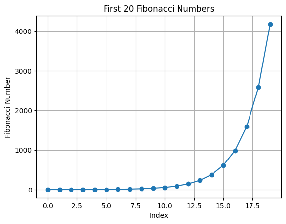

```python
import matplotlib.pyplot as plt

def fibonacci(n):
    fib_sequence = [0, 1]
    while len(fib_sequence) < n:
        fib_sequence.append(fib_sequence[-1] + fib_sequence[-2])
    return fib_sequence[:n]

# Generate the first 20 Fibonacci numbers
n = 20
fib_sequence = fibonacci(n)

# Plot the Fibonacci sequence
plt.plot(fib_sequence, marker='o')
plt.title(f'First {n} Fibonacci Numbers')
plt.xlabel('Index')
plt.ylabel('Fibonacci Number')
plt.grid(True)
plt.show()
```

### 4. List Manipulation

1. Given a list [3, 5, 7, 9, 11, 13]:
   - Insert 6 at the 3rd index.
   - Remove the number 7 from the list.
   - Reverse the list.
   - Calculate the mean and median of the modified list.

```python
# Given list
lst = [3, 5, 7, 9, 11, 13]

# Insert 6 at the 3rd index
lst.insert(3, 6)

# Remove the number 7 from the list
lst.remove(7)

# Reverse the list
lst.reverse()

# Calculate the mean and median of the modified list
mean_modified = np.mean(lst)
median_modified = np.median(lst)

print(f"Modified list: {lst}")
print(f"Mean of modified list: {mean_modified}")
print(f"Median of modified list: {median_modified}")
```

```
Modified list: [13, 11, 9, 6, 5, 3]
Mean of modified list: 7.833333333333333
Median of modified list: 7.5
```

### 5. User Input and Basic Statistics

1. Write a program to read a comma-separated list of numbers from the user (e.g., “10, 20, 30, 40”).
2. Calculate the mean of the numbers.
3. Identify and print the smallest and largest numbers.
4. Plot a histogram of the numbers

```
Mean of the numbers: 28.25
Smallest number: 2
Largest number: 66
```

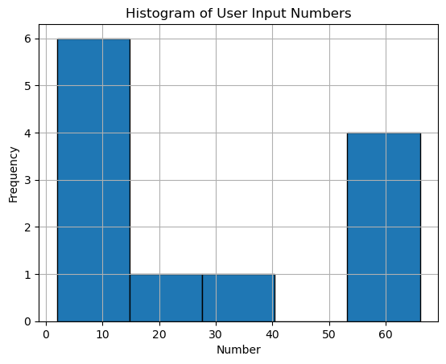

```python
# 1. Read a comma-separated list of numbers from the user
user_input = input("Enter a comma-separated list of numbers: ")
numbers = list(map(int, user_input.split(',')))

# 2. Calculate the mean of the numbers
mean_user_numbers = np.mean(numbers)

# 3. Identify and print the smallest and largest numbers
smallest_number = min(numbers)
largest_number = max(numbers)

print(f"Mean of the numbers: {mean_user_numbers}")
print(f"Smallest number: {smallest_number}")
print(f"Largest number: {largest_number}")

# 4. Plot a histogram of the numbers
plt.hist(numbers, bins='auto', edgecolor='black')
plt.title('Histogram of User Input Numbers')
plt.xlabel('Number')
plt.ylabel('Frequency')
plt.grid(True)
plt.show()
```

### 6. Palindrome Check

1. Write a program to check if a string is a palindrome (ignoring spaces and case).
   - Input: "A man a plan a canal Panama"
   - Output: True

```python
def is_palindrome(s):
    # Remove spaces and convert to lowercase
    cleaned_str = ''.join(s.split()).lower()
    # Check if the cleaned string is equal to its reverse
    return cleaned_str == cleaned_str[::-1]

# Test the function
input_str = "A man a plan a canal Panama"
print(is_palindrome(input_str))  # Output: True
```

```
True
```

### 7. Dictionary Operations

1. Create a dictionary of student names (keys) and their marks (values).
2. Compute the average marks.
3. Print the names of students scoring above the average.
4. Visualize the distribution of marks using a bar chart.

```
Average marks: 83.8
Students scoring above the average:
Alice
Charlie
David
```

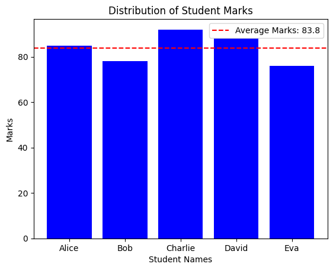

```python
# 1. Create a dictionary of student names (keys) and their marks (values).
student_marks = {
    'Alice': 85,
    'Bob': 78,
    'Charlie': 92,
    'David': 88,
    'Eva': 76
}

# 2. Compute the average marks.
average_marks = np.mean(list(student_marks.values()))

# 3. Print the names of students scoring above the average.
above_average_students = [name for name, marks in student_marks.items() if marks > average_marks]
print(f"Average marks: {average_marks}")
print("Students scoring above the average:")
for student in above_average_students:
    print(student)

# 4. Visualize the distribution of marks using a bar chart.
plt.bar(student_marks.keys(), student_marks.values(), color='blue')
plt.axhline(y=average_marks, color='r', linestyle='--', label=f'Average Marks: {average_marks}')
plt.xlabel('Student Names')
plt.ylabel('Marks')
plt.title('Distribution of Student Marks')
plt.legend()
plt.show()
```

### 8. Tuple List Creation

1. Create a list of tuples, where each tuple contains a number and its square (e.g., [(1, 1), (2, 4), (3, 9), ...] for numbers 1 to 10).
2. Plot the numbers and their squares on a scatter plot.

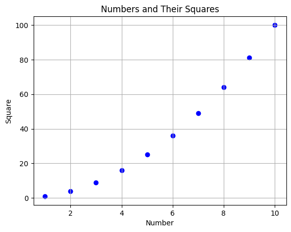

```python
# 1. Create a list of tuples, where each tuple contains a number and its square.
numbers_and_squares = [(num, num**2) for num in range(1, 11)]

# 2. Plot the numbers and their squares on a scatter plot.
x_values, y_values = zip(*numbers_and_squares)

plt.scatter(x_values, y_values, color='blue', marker='o')
plt.title('Numbers and Their Squares')
plt.xlabel('Number')
plt.ylabel('Square')
plt.grid(True)
plt.show()
```

### 9. Merging Dictionaries

1. Write Python code to merge two dictionaries. If a key is present in both, sum their values.
   - Example:
     - dict1 = {'a': 10, 'b': 20}
     - dict2 = {'b': 5, 'c': 15}
   - Output: {'a': 10, 'b': 25, 'c': 15}

```python
def merge_dictionaries(dict1, dict2):
    merged_dict = dict1.copy()  # Start with dict1's keys and values
    for key, value in dict2.items():
        if key in merged_dict:
            merged_dict[key] += value  # If key is in both, sum the values
        else:
            merged_dict[key] = value  # If key is only in dict2, add it to merged_dict
    return merged_dict

# Example dictionaries
dict1 = {'a': 10, 'b': 20}
dict2 = {'b': 5, 'c': 15}

# Merging the dictionaries
merged_dict = merge_dictionaries(dict1, dict2)
print(merged_dict)  # Output: {'a': 10, 'b': 25, 'c': 15}
```

```
{'a': 10, 'b': 25, 'c': 15}
```

### 10. Character Frequency

1. Write a function that accepts a string and:
   - Converts all characters to lowercase.
   - Counts the frequency of each character.
   - Returns a dictionary with characters as keys and their counts as values.
2. Visualize the character frequencies using a bar chart.

```
{'a': 10, 'm': 2, 'n': 4, 'p': 2, 'l': 2, 'c': 1, 'space': 6}
```

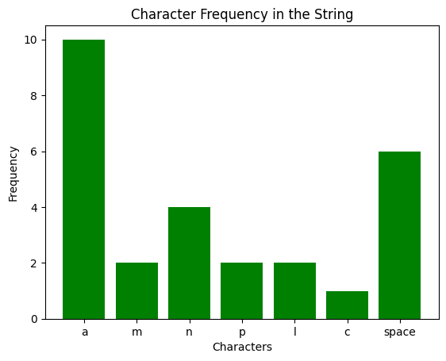

```python
def character_frequency(s):
    # Convert all characters to lowercase
    s = s.lower()
    # Count the frequency of each character
    freq_dict = {}
    for char in s:
        if char in freq_dict:
            freq_dict[char] += 1
        else:
            freq_dict[char] = 1
    return freq_dict

# Example string
example_string = "A man a plan a canal Panama"

# Get the character frequency dictionary
char_freq = character_frequency(example_string)
if ' ' in char_freq:
    char_freq['space'] = char_freq[' ']
    del char_freq[' ']

print(char_freq)

# Visualize the character frequencies using a bar chart
plt.bar(char_freq.keys(), char_freq.values(), color='green')
plt.xlabel('Characters')
plt.ylabel('Frequency')
plt.title('Character Frequency in the String')
plt.show()
```

### 11. Remove Duplicates

1. Write a program to remove duplicate elements from a list while maintaining the order of elements.
2. Calculate the mean and median of the unique elements.

```python
# Given list with duplicates
duplicate_list = [1, 2, 2, 3, 4, 4, 5, 6, 6, 7, 8, 8, 9, 10, 10]

# 1. Remove duplicate elements while maintaining the order
unique_list = []
seen = set()
for item in duplicate_list:
    if item not in seen:
        unique_list.append(item)
        seen.add(item)

# 2. Calculate the mean and median of the unique elements
mean_unique = np.mean(unique_list)
median_unique = np.median(unique_list)

print(f"Unique list: {unique_list}")
print(f"Mean of unique elements: {mean_unique}")
print(f"Median of unique elements: {median_unique}")
```

```
Unique list: [1, 2, 3, 4, 5, 6, 7, 8, 9, 10]
Mean of unique elements: 5.5
Median of unique elements: 5.5
```

### 12. String Operations

1. Given a list of strings, write a Python function to:
   - Find the longest string.
   - Count how many strings start with a vowel.
   - Visualize the distribution of string lengths using a histogram.

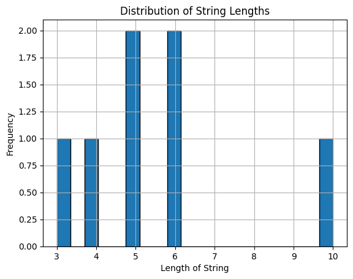

```
Longest string: elderberry
Number of strings starting with a vowel: 2
```

```python
def string_operations(strings):
    # Find the longest string
    longest_string = max(strings, key=len)

    # Count how many strings start with a vowel
    vowels = 'aeiouAEIOU'
    count_vowel_start = sum(1 for s in strings if s and s[0] in vowels)

    # Visualize the distribution of string lengths using a histogram
    string_lengths = [len(s) for s in strings]
    plt.hist(string_lengths, bins=20, edgecolor='black')
    plt.title('Distribution of String Lengths')
    plt.xlabel('Length of String')
    plt.ylabel('Frequency')
    plt.grid(True)
    plt.show()

    return longest_string, count_vowel_start

# Example list of strings
strings = ["apple", "banana", "cherry", "date", "elderberry", "fig", "grape"]

# Perform string operations
longest_string, count_vowel_start = string_operations(strings)
print(f"Longest string: {longest_string}")
print(f"Number of strings starting with a vowel: {count_vowel_start}")
```

### 13. Sorting Dictionaries

1. Write a function to sort a list of dictionaries by a key.
   - Example:
     - data = [{'name': 'Alice', 'age': 25}, {'name': 'Bob', 'age': 22}]
     - Sort by age → [{'name': 'Bob', 'age': 22}, {'name': 'Alice', 'age': 25}]

```python
def sort_dicts_by_key(data, key):
    return sorted(data, key=lambda x: x[key])

# Example data
data = [{'name': 'Alice', 'age': 25}, {'name': 'Bob', 'age': 22}]

# Sort by age
sorted_data = sort_dicts_by_key(data, 'age')
print(sorted_data)  # Output: [{'name': 'Bob', 'age': 22}, {'name': 'Alice', 'age': 25}]
```

```
[{'name': 'Bob', 'age': 22}, {'name': 'Alice', 'age': 25}]
```

### 14. Word Filtering and Sorting

1. Write a program to:
   - Split a string into a list of words.
   - Remove all words that are shorter than 4 characters.
   - Sort the remaining words alphabetically.
   - Visualize the word lengths using a bar chart.

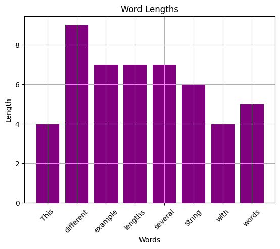

```
Sorted words: ['This', 'different', 'example', 'lengths', 'several', 'string', 'with', 'words']
```

```python
def filter_and_sort_words(input_string):
    # Split the string into a list of words
    words = input_string.split()

    # Remove all words that are shorter than 4 characters
    filtered_words = [word for word in words if len(word) >= 4]

    # Sort the remaining words alphabetically
    sorted_words = sorted(filtered_words)

    # Visualize the word lengths using a bar chart
    word_lengths = [len(word) for word in sorted_words]
    plt.bar(sorted_words, word_lengths, color='purple')
    plt.xlabel('Words')
    plt.ylabel('Length')
    plt.title('Word Lengths')
    plt.xticks(rotation=45)
    plt.grid(True)
    plt.show()

    return sorted_words

# Example input string
input_string = "This is an example string with several words of different lengths"

# Perform word filtering and sorting
sorted_words = filter_and_sort_words(input_string)
print(f"Sorted words: {sorted_words}")
```

### 15. Anagram Finder

1. Write a Python function to find all anagrams of a word in a given list.
   - Input: word = "listen", words = ["enlist", "google", "inlets", "banana"]
   - Output: ["enlist", "inlets"]

```python
def find_anagrams(word, words):
    sorted_word = sorted(word)
    return [w for w in words if sorted(w) == sorted_word]

# Example input
word = "listen"
words = ["enlist", "google", "inlets", "banana"]

# Find anagrams
anagrams = find_anagrams(word, words)
print(anagrams)  # Output: ["enlist", "inlets"]
```

```
['enlist', 'inlets']
```

### 16. Set Operations

1. Given two lists, write Python code to find their intersection, union, and symmetric difference.
2. Visualize the results using Venn diagrams.

```
Intersection: {4, 5}
Union: {1, 2, 3, 4, 5, 6, 7, 8}
Symmetric Difference: {1, 2, 3, 6, 7, 8}
```

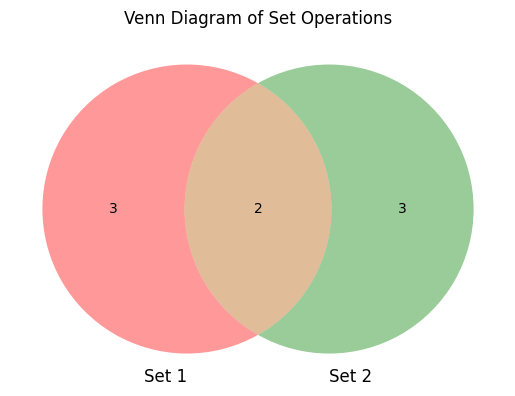

```python
from matplotlib_venn import venn2

# Given lists
list1 = [1, 2, 3, 4, 5]
list2 = [4, 5, 6, 7, 8]

# Convert lists to sets
set1 = set(list1)
set2 = set(list2)

# Find intersection, union, and symmetric difference
intersection = set1 & set2
union = set1 | set2
symmetric_difference = set1 ^ set2

print(f"Intersection: {intersection}")
print(f"Union: {union}")
print(f"Symmetric Difference: {symmetric_difference}")

# Visualize the results using Venn diagrams
venn2([set1, set2], ('Set 1', 'Set 2'))
plt.title('Venn Diagram of Set Operations')
plt.show()
```

### 17. File Operations

1. Write Python code to:
   - Create a text file.
   - Write a list of numbers to the file (one per line).
   - Read the file and compute their sum.

```python
# List of numbers to write to the file
numbers_to_write = [1, 2, 3, 4, 5, 6, 7, 8, 9, 10]

# Create a text file and write the list of numbers to the file (one per line)
with open('numbers.txt', 'w') as file:
    for number in numbers_to_write:
        file.write(f"{number}\n")

# Read the file and compute the sum of the numbers
with open('numbers.txt', 'r') as file:
    numbers_from_file = [int(line.strip()) for line in file]

sum_of_numbers = sum(numbers_from_file)
print(f"Sum of numbers from file: {sum_of_numbers}")
```

```
Sum of numbers from file: 55
```

### 18. Word Count and Frequency

1. Write a program to:
   - Read a file and count the number of words in it.
   - Find the most frequent word.
   - Visualize the word frequencies using a bar chart.

```
Number of words in the file: 10
Most frequent word: 1 (Frequency: 1)
```

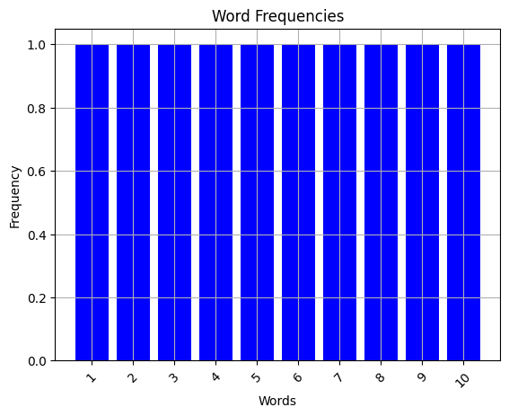

```python
from collections import Counter

# Read the file and count the number of words
with open('numbers.txt', 'r') as file:
    text = file.read()
    words = text.split()
    word_count = len(words)

# Find the most frequent word
word_freq = Counter(words)
most_frequent_word = word_freq.most_common(1)[0]

print(f"Number of words in the file: {word_count}")
print(f"Most frequent word: {most_frequent_word[0]} (Frequency: {most_frequent_word[1]})")

# Visualize the word frequencies using a bar chart
plt.bar(word_freq.keys(), word_freq.values(), color='blue')
plt.xlabel('Words')
plt.ylabel('Frequency')
plt.title('Word Frequencies')
plt.xticks(rotation=45)
plt.grid(True)
plt.show()
```

### 19. Random Number Generation

1. Write a Python program to:
   - Generate 100 random integers between 1 and 50.
   - Save them in a text file, one per line.
   - Read the file and compute the mean of the numbers.
   - Visualize the distribution of the numbers using a histogram.

```
Mean of the random numbers: 27.07
```

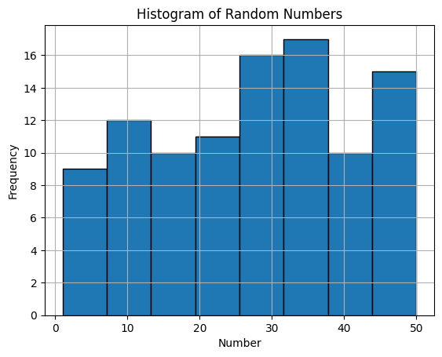

```python
import random

# Generate 100 random integers between 1 and 50
random_numbers = [random.randint(1, 50) for _ in range(100)]

# Save them in a text file, one per line
with open('random_numbers.txt', 'w') as file:
    for number in random_numbers:
        file.write(f"{number}\n")

# Read the file and compute the mean of the numbers
with open('random_numbers.txt', 'r') as file:
    numbers_from_file = [int(line.strip()) for line in file]

mean_random_numbers = np.mean(numbers_from_file)
print(f"Mean of the random numbers: {mean_random_numbers}")

# Visualize the distribution of the numbers using a histogram
plt.hist(numbers_from_file, bins='auto', edgecolor='black')
plt.title('Histogram of Random Numbers')
plt.xlabel('Number')
plt.ylabel('Frequency')
plt.grid(True)
plt.show()
```

### 20. CSV File Operations

1. Write Python code to read a CSV file and compute the sum of values in a specific column.
2. Visualize the data using a line plot.

```
Sum of values in column 'values': 2707
```

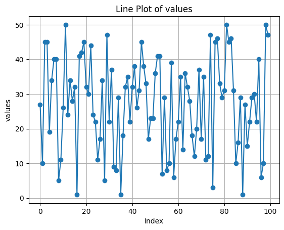

```python
import pandas as pd

# Read the CSV file
csv_file = 'data.csv'
df = pd.read_csv(csv_file)

# Compute the sum of values in a specific column (e.g., 'column_name')
column_name = 'values'
sum_column = df[column_name].sum()
print(f"Sum of values in column '{column_name}': {sum_column}")

# Visualize the data using a line plot
df[column_name].plot(kind='line', marker='o')
plt.title(f'Line Plot of {column_name}')
plt.xlabel('Index')
plt.ylabel(column_name)
plt.grid(True)
plt.show()
```

### 21 .Basic Statistics

1. Write Python code to calculate:
   - Mean, median, mode, and standard deviation of a list of numbers.
2. Visualize the data using a box plot.

[output not shown]

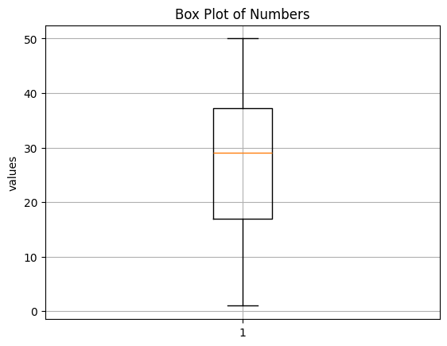

```python
from scipy import stats

# Read the list of numbers from data.csv
column_name = 'values'
numbers = df[column_name]

# Calculate mean, median, mode, and standard deviation
mean_value = np.mean(numbers)
median_value = np.median(numbers)
mode_value = stats.mode(numbers)[0]
std_dev_value = np.std(numbers)

print(f"Mean: {mean_value}")
print(f"Median: {median_value}")
print(f"Mode: {stats.mode(numbers)}")
print(f"Standard Deviation: {std_dev_value}")

# Visualize the data using a box plot
plt.boxplot(numbers)
plt.title('Box Plot of Numbers')
plt.ylabel(column_name)
plt.grid(True)
plt.show()
```

### 22. Normalization

1. Write a Python function to normalize a list of numbers to a range of 0 to 1.
2. Visualize the normalized data using a line plot.

```
Numbers: [27, 10, 45, 45, 19, 34, 40, 40, 5]
Normalized Numbers: [0.55, 0.125, 1.0, 1.0, 0.35, 0.725, 0.875, 0.875, 0.0]
```

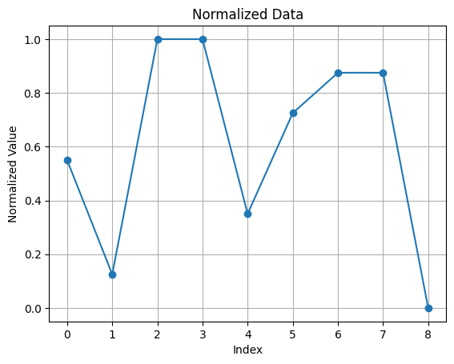

```python
def normalize(numbers):
    min_val = min(numbers)
    max_val = max(numbers)
    return [(num - min_val) / (max_val - min_val) for num in numbers]

# Normalize the numbers from the DataFrame
numbers = [27, 10, 45, 45, 19, 34, 40, 40, 5]
print('Numbers:' , numbers)
normalized_numbers = normalize(numbers)
print('Normalized Numbers:' , normalized_numbers)

# Visualize the normalized data using a line plot
plt.plot(normalized_numbers, marker='o')
plt.title('Normalized Data')
plt.xlabel('Index')
plt.ylabel('Normalized Value')
plt.grid(True)
plt.show()
```

### 23. Even or Odd

1. Write a Python program that takes an integer input from the user and prints whether the number is even or odd.

```python
# Take an integer input from the user
user_input = int(input("Enter an integer: "))

# Check if the number is even or odd
if user_input % 2 == 0:
    print(f"The number {user_input} is even.")
else:
    print(f"The number {user_input} is odd.")
```

```
The number 10 is even.
```

### 24. Grade Calculator

1. Write a Python program that takes a numerical grade (0-100) as input and prints the corresponding letter grade (A, B, C, D, F).

```python
# Function to convert numerical grade to letter grade
def grade_calculator(numerical_grade):
    if 90 <= numerical_grade <= 100:
        return 'A'
    elif 80 <= numerical_grade < 90:
        return 'B'
    elif 70 <= numerical_grade < 80:
        return 'C'
    elif 60 <= numerical_grade < 70:
        return 'D'
    else:
        return 'F'

# Take a numerical grade as input from the user
numerical_grade = int(input("Enter a numerical grade (0-100): "))

# Get the corresponding letter grade
letter_grade = grade_calculator(numerical_grade)

# Print the letter grade
print(f"The letter grade for {numerical_grade} is {letter_grade}.")
```

```
The letter grade for 78 is C.
```

### 25. Leap Year Checker

1. Write a Python program that takes a year as input and checks if it is a leap year.

```python
def is_leap_year(year):
    if (year % 4 == 0 and year % 100 != 0) or (year % 400 == 0):
        return True
    else:
        return False

# Take a year as input from the user
year = int(input("Enter a year: "))

# Check if the year is a leap year
if is_leap_year(year):
    print(f"{year} is a leap year.")
else:
    print(f"{year} is not a leap year.")
```

```
2014 is not a leap year.
```